# R Notebook

```r
if ("all_month.csv" %in% dir(".") == FALSE) {
  url <- "https://earthquake.usgs.gov/earthquakes/feed/v1.0/summary/all_month.csv"
  download.file(url = url, destfile = "all_month.csv")
}
quakes <- read.csv("all_month.csv", header=TRUE, sep=',', stringsAsFactors = FALSE)
```

How many lines are in our dataset?

```r
  dim(quakes)
```

```
## [1] 16803    22
```

Increasing date ordering.

```r
quakes = arrange(quakes, -row_number())
```

Lets have a look at the data.

```r
head(quakes)
```

|  | time | latitude | longitude | depth | mag | magType | nst | gap | dmin | rms | net | id | updated | place | type | horizontalError | depthError | magError | magNst | status | locationSource | magSource |
| --- | --- | --- | --- | --- | --- | --- | --- | --- | --- | --- | --- | --- | --- | --- | --- | --- | --- | --- | --- | --- | --- | --- |
| 1 | 2019-08-02T15:01:50.000Z | 40.33733 | -124.4283 | 17.68 | 1.60 | md | 14 | 260 | 0.081760 | 0.11 | nc | nc73240836 | 2019-08-07T00:14:02.570Z | 12km W of Petrolia, CA | earthquake | 2.39 | 1.04 | 0.077 | 7 | reviewed | nc | nc |
| 2 | 2019-08-02T15:06:51.470Z | 35.78450 | -117.6205 | 8.31 | 2.45 | ml | 31 | 52 | 0.119800 | 0.17 | ci | ci38684391 | 2019-08-02T15:17:56.890Z | 19km NNE of Ridgecrest, CA | earthquake | 0.23 | 0.94 | 0.161 | 25 | automatic | ci | ci |
| 3 | 2019-08-02T15:08:34.631Z | 60.47240 | -152.7339 | 2.10 | 0.70 | ml | NA | NA | NA | 0.30 | ak | ak0199u5zjeh | 2019-08-30T15:44:34.660Z | 1km SSE of Redoubt Volcano, Alaska | earthquake | NA | 0.30 | NA | NA | reviewed | ak | ak |
| 4 | 2019-08-02T15:08:55.200Z | 38.82383 | -122.8003 | 1.70 | 0.79 | md | 12 | 71 | 0.007623 | 0.03 | nc | nc73240846 | 2019-08-02T15:47:03.564Z | 6km NW of The Geysers, CA | earthquake | 0.32 | 0.58 | 0.120 | 2 | automatic | nc | nc |
| 5 | 2019-08-02T15:15:57.150Z | 35.37950 | -117.8457 | 3.89 | 0.99 | ml | 16 | 100 | 0.111800 | 0.11 | ci | ci38684399 | 2019-08-02T17:47:03.090Z | 19km W of Johannesburg, CA | earthquake | 0.27 | 0.90 | 0.142 | 13 | reviewed | ci | ci |
| 6 | 2019-08-02T15:17:22.727Z | -6.15370 | 128.6222 | 323.51 | 4.40 | mb | NA | 125 | 3.218000 | 0.91 | us | us60004zm8 | 2019-08-19T14:05:10.040Z | 273km S of Amahusu, Indonesia | earthquake | 11.50 | 8.90 | 0.120 | 20 | reviewed | us | us |

```r
tail(quakes)
```

|  | time | latitude | longitude | depth | mag | magType | nst | gap | dmin | rms | net | id | updated | place | type | horizontalError | depthError | magError | magNst | status | locationSource | magSource |
| --- | --- | --- | --- | --- | --- | --- | --- | --- | --- | --- | --- | --- | --- | --- | --- | --- | --- | --- | --- | --- | --- | --- |
| 16798 | 2019-09-01T14:36:41.730Z | 48.39133 | -122.8217 | 3.84 | 2.02 | md | 32 | 57 | NA | 0.17 | uw | uw61547551 | 2019-09-01T14:43:07.500Z | 12km WNW of Ault Field, Washington | earthquake | 0.31 | 2.03 | 0.250 | 5 | reviewed | uw | uw |
| 16799 | 2019-09-01T14:40:58.300Z | 35.59967 | -117.5947 | 3.91 | 0.77 | ml | 13 | 70 | 0.03053 | 0.25 | ci | ci39032888 | 2019-09-01T14:44:34.299Z | 8km ESE of Ridgecrest, CA | earthquake | 0.44 | 0.84 | 0.250 | 9 | automatic | ci | ci |
| 16800 | 2019-09-01T14:42:43.630Z | 35.59533 | -117.3992 | 8.76 | 1.04 | ml | 20 | 101 | 0.05213 | 0.21 | ci | ci39032896 | 2019-09-01T14:46:28.294Z | 19km S of Trona, CA | earthquake | 0.40 | 0.72 | 0.118 | 12 | automatic | ci | ci |
| 16801 | 2019-09-01T14:46:24.560Z | 33.32317 | -116.4032 | 6.32 | 0.81 | ml | 34 | 87 | 0.05606 | 0.18 | ci | ci39032904 | 2019-09-01T14:50:08.255Z | 8km NNW of Borrego Springs, CA | earthquake | 0.30 | 0.62 | 0.148 | 21 | automatic | ci | ci |
| 16802 | 2019-09-01T14:47:47.980Z | 33.21700 | -116.3687 | 8.49 | 0.75 | ml | 29 | 86 | 0.06526 | 0.24 | ci | ci39032912 | 2019-09-01T14:51:29.324Z | 4km S of Borrego Springs, CA | earthquake | 0.43 | 0.89 | 0.092 | 15 | automatic | ci | ci |
| 16803 | 2019-09-01T14:57:58.654Z | 65.22100 | -148.7666 | 15.30 | 1.20 | ml | NA | NA | NA | 0.44 | ak | ak019b7rt3ax | 2019-09-01T15:01:11.679Z | 54km NW of Ester, Alaska | earthquake | NA | 0.30 | NA | NA | automatic | ak | ak |

```r
str(quakes)
```

```
## 'data.frame':    16803 obs. of  22 variables:
##  $ time           : chr  "2019-08-02T15:01:50.000Z" "2019-08-02T15:06:51.470Z" "2019-08-02T15:08:34.631Z" "2019-08-02T15:08:55.200Z" ...
##  $ latitude       : num  40.3 35.8 60.5 38.8 35.4 ...
##  $ longitude      : num  -124 -118 -153 -123 -118 ...
##  $ depth          : num  17.68 8.31 2.1 1.7 3.89 ...
##  $ mag            : num  1.6 2.45 0.7 0.79 0.99 4.4 3.34 1 1.75 1.11 ...
##  $ magType        : chr  "md" "ml" "ml" "md" ...
##  $ nst            : int  14 31 NA 12 16 NA 60 NA 26 12 ...
##  $ gap            : num  260 52 NA 71 100 125 29 NA 52 141 ...
##  $ dmin           : num  0.08176 0.1198 NA 0.00762 0.1118 ...
##  $ rms            : num  0.11 0.17 0.3 0.03 0.11 0.91 0.15 0.33 0.23 0.24 ...
##  $ net            : chr  "nc" "ci" "ak" "nc" ...
##  $ id             : chr  "nc73240836" "ci38684391" "ak0199u5zjeh" "nc73240846" ...
##  $ updated        : chr  "2019-08-07T00:14:02.570Z" "2019-08-02T15:17:56.890Z" "2019-08-30T15:44:34.660Z" "2019-08-02T15:47:03.564Z" ...
##  $ place          : chr  "12km W of Petrolia, CA" "19km NNE of Ridgecrest, CA" "1km SSE of Redoubt Volcano, Alaska" "6km NW of The Geysers, CA" ...
##  $ type           : chr  "earthquake" "earthquake" "earthquake" "earthquake" ...
##  $ horizontalError: num  2.39 0.23 NA 0.32 0.27 11.5 0.1 NA 0.26 0.59 ...
##  $ depthError     : num  1.04 0.94 0.3 0.58 0.9 8.9 0.17 0.5 0.58 0.5 ...
##  $ magError       : num  0.077 0.161 NA 0.12 0.142 0.12 0.135 NA 0.128 0.101 ...
##  $ magNst         : int  7 25 NA 2 13 20 113 NA 26 9 ...
##  $ status         : chr  "reviewed" "automatic" "reviewed" "automatic" ...
##  $ locationSource : chr  "nc" "ci" "ak" "nc" ...
##  $ magSource      : chr  "nc" "ci" "ak" "nc" ...
```

## a short description of the variables

time: time of event latitude: decimal degrees latitude. Negative values for southern latitudes. Range is [-90.0,90.0] longitude: decimal degrees longitude. Negative values for western longitudes. [-180.0,180.0] depth: depth of the event in kilometers mag: magnitude for the event. Range [-1.0, 10.0] magType: method or algorithm used to calculate the preferred magnitude for the event nst: total number of seismic stations used to determine earthquake location gap: largest azimuthal gap between azimuthally adjacent stations (in degrees) dmin: horizontal distance from the epicenter to the nearest station (in degrees) rms: root-mean-square (RMS) travel time residual, in sec, using all weights net: ID of data contributor. Identifies the network considered to be the preferred source of information for this event id: unique identifier for the event. This is the current preferred id for the event, and may change over time updated: time when the event was most recently updated place: textual description of named geographic region near to the event. This may be a city name, or a Flinn-Engdahl Region name type: type of seismic event horizontalError: uncertainty of reported location of the event in kilometers depthError: uncertainty of reported depth of the event in kilometers magError: uncertainty of reported magnitude of the event magNst: total number of seismic stations used to calculate the magnitude status: indicates whether the event has been reviewed by a human locationSource: network that originally authored the reported location of this event magSource: network that originally authored the reported magnitude for this event

## A sort exploratory analysis

```r
(numeric_vars <- names(which(sapply(quakes, class) == "numeric")))
```

```
##  [1] "latitude"        "longitude"       "depth"
##  [4] "mag"             "gap"             "dmin"
##  [7] "rms"             "horizontalError" "depthError"
## [10] "magError"
```

```r
(integer_vars <- names(which(sapply(quakes, class) == "ineger")))
```

```
## character(0)
```

```r
(factor_vars <- names(which(sapply(quakes, class) == "factor")))
```

```
## character(0)
```

```r
(character_vars <- names(which(sapply(quakes, class) == "character")))
```

```
##  [1] "time"           "magType"        "net"            "id"
##  [5] "updated"        "place"          "type"           "status"
##  [9] "locationSource" "magSource"
```

# Map (static)

Because we have lattitude and logitude data we can make this a static map.

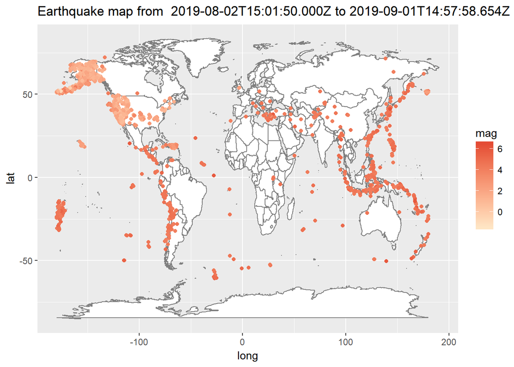

```r
world <- map_data('world')

title <- paste("Earthquake map from ", paste(quakes$time[1], quakes$time[nrow(quakes)], sep = " to "))

p <- ggplot() + geom_map(data = world, map = world, aes(x = long, y=lat, group=group, map_id=region), fill="white", colour="#7f7f7f", size=0.5)
p <- p + geom_point(data = quakes, aes(x=longitude, y = latitude, colour = mag)) + scale_colour_gradient(low = "#fee8c8",high = "#e34a33") + ggtitle(title)
p
```

# Map (interactive)

```r
quakes %>% leaflet() %>% addTiles() %>%
  addMarkers(~longitude, ~latitude,
             popup = (paste("Place: ", quakes$place, "<br>",
                            "Id: ", quakes$id, "<br>",
                            "Time: ", quakes$time, "<br>",
                            "Magnitude: ", quakes$mag, " m <br>",
                            "Depth: ", quakes$depth)),
             clusterOptions = markerClusterOptions())
```

[interactive chart not shown]